# Структура научной презентации

Простейший шаблон

Басманова Д.К.

Российский университет дружбы народов, Москва, Россия

03 марта 2023

# Информация

## Докладчик

- Басманова Дарья Кирилловна
- Российский университет дружбы народов

# Вводная часть

## Актуальность

Работа актуальна для тех, кто хочет научиться взаимодействать пользователя с системой посредством командной строки.

## Цели и задачи

Приобретение практических навыков взаимодействия пользователя с системой посредством командной строки

# Создание презентации

## Процессор `pandoc`

- Pandoc: преобразователь текстовых файлов
- Сайт: https://pandoc.org/
- Репозиторий: https://github.com/jgm/pandoc

## Формат `pdf`

- Использование LaTeX
- Пакет для презентации: beamer
- Тема оформления: `metropolis`

## Код для формата `pdf`

```yaml
slide_level: 2
aspectratio: 169
section-titles: true
theme: metropolis
```

## Формат `html`

- Используется фреймворк [reveal.js](https://revealjs.com/)
- Используется [тема](https://revealjs.com/themes/) `beige`

## Код для формата `html`

- Тема задаётся в файле `Makefile`

```
REVEALJS_THEME = beige
```

# Результаты

## Получающиеся форматы

- Полученный `pdf`-файл можно демонстрировать в любой программе просмотра `pdf`
- Полученный `html`-файл содержит в себе все ресурсы: изображения, css, скрипты

# Процесс лабораторной

## 1. Первым делом переходим в каталог /tmp и выводим содержимое этого каталога с помощью команды ls.

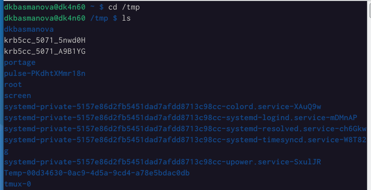

Переходим в каталог

## №2. Проверяем есть ли в каталоге /var/spool подкаталог с именем cron. Он есть.

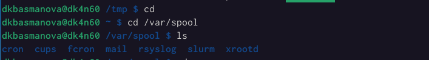

Проверяем каталог

## 3. Переходим с помощью команды cd в наш домашний каталог, выводим содержимое каталога.

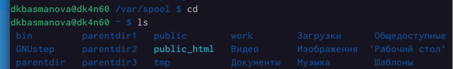

Переход в каталог

## 4. Создаем в домашшнем каталоге новый каталог с именем newdir. Проверяем создали ли его.

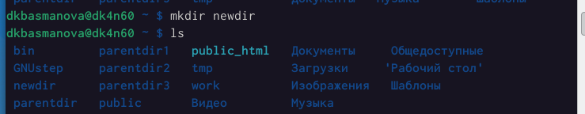

Создание каталога

## 5. Создадим каталог morefun в каталоге newdir. Проверяем.

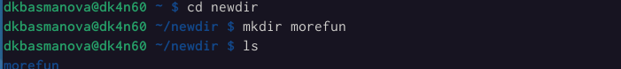

Создание каталога

## 6. Создадим одной командой три новых каталога с именами letters, memos, misk. Затем одной командой их удалим.

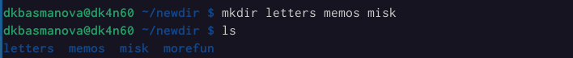

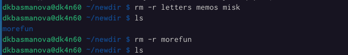

## 8. Удаляем каталог morefun. Проверяем.

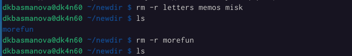

Удаление каталога

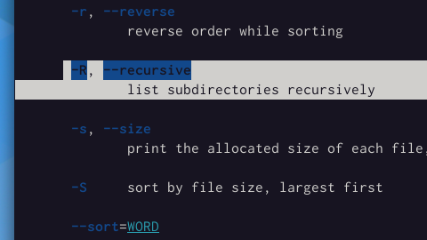

## 10. С помощью команды просмотрим описания следующих команд: cd, pwd, mkdir, rmdir, rm.

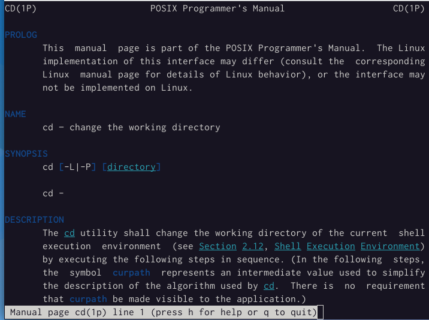

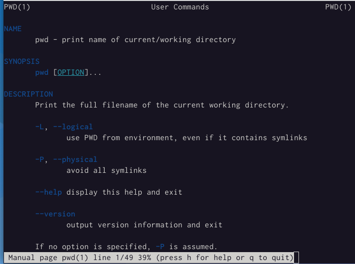

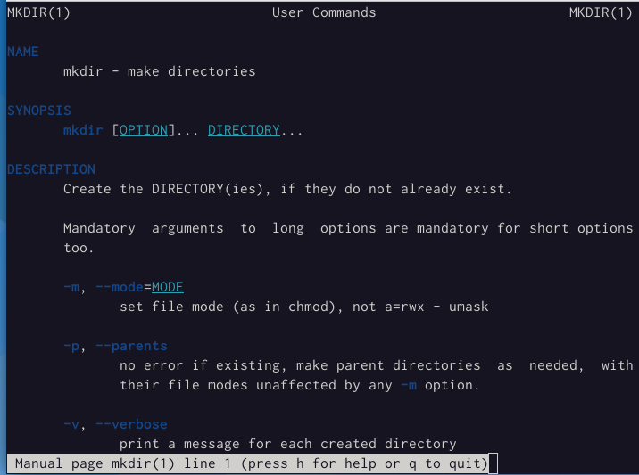

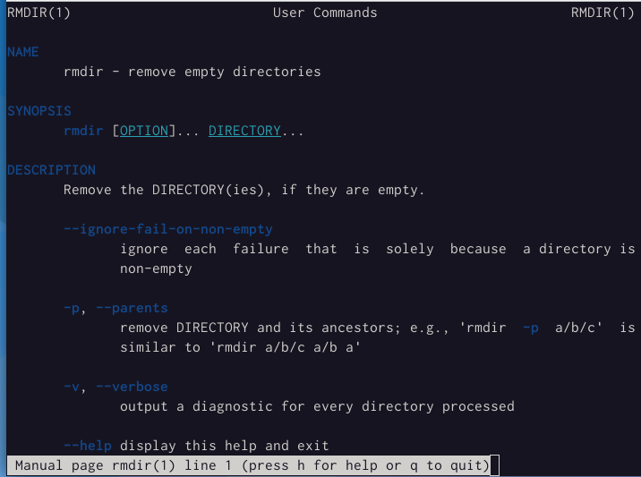

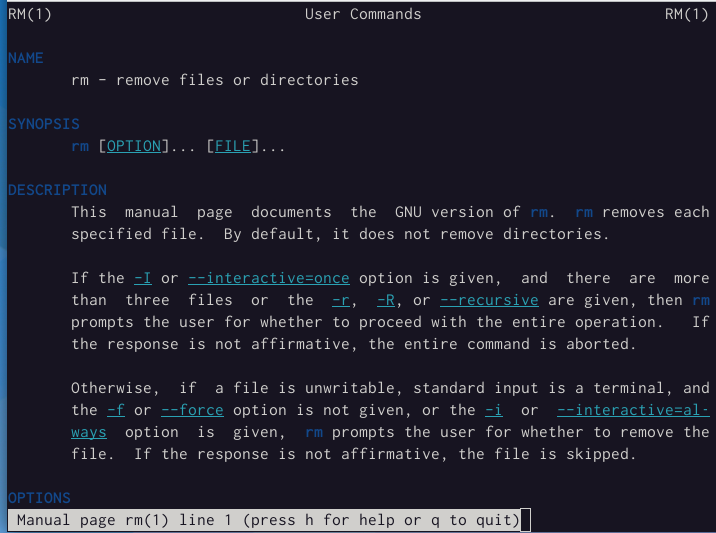

## 11. Используя информацию, полученную при помощи команды history, выполним модификацию и исполнение нескольких команд из буфера команд

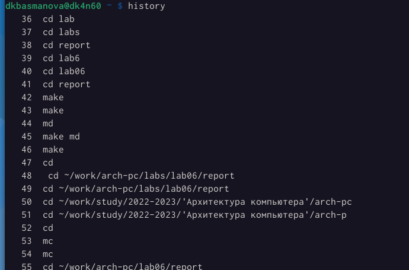

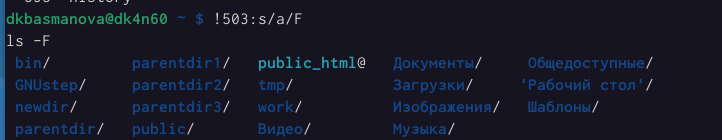

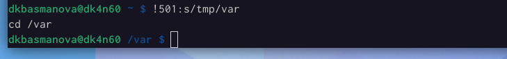

## Итоговый слайд

Я приобрела практические навыки взаимодействия пользователя с системой посредством командной строки.